# Risk Factor Analysis

## Outcome Variable

**Outcome Variable:** ever_stunted

## Predictor Variables

**Intervention Variable:** vagbrth

**Adjustment Set:**

- arm
- sex
- W_mage
- meducyrs
- feducyrs
- W_mhtcm
- W_mwtkg
- W_mbmi
- single
- brthmon
- W_parity
- delta_W_mage
- delta_meducyrs
- delta_feducyrs
- delta_W_mhtcm
- delta_W_mwtkg
- delta_W_mbmi
- delta_single
- delta_brthmon
- delta_W_parity

## Stratifying Variables

The analysis was stratified on these variable(s):

- agecat
- studyid
- country

## Data Summary

| agecat | studyid | country | vagbrth | ever_stunted | n_cell | n |
| --- | --- | --- | --- | --- | --- | --- |
| 0-24 months (no birth st.) | CMC-V-BCS-2002 | INDIA | 0 | 0 | 3 | 296 |
| 0-24 months (no birth st.) | CMC-V-BCS-2002 | INDIA | 0 | 1 | 17 | 296 |
| 0-24 months (no birth st.) | CMC-V-BCS-2002 | INDIA | 1 | 0 | 25 | 296 |
| 0-24 months (no birth st.) | CMC-V-BCS-2002 | INDIA | 1 | 1 | 251 | 296 |
| 0-24 months (no birth st.) | IRC | INDIA | 0 | 0 | 24 | 360 |
| 0-24 months (no birth st.) | IRC | INDIA | 0 | 1 | 35 | 360 |
| 0-24 months (no birth st.) | IRC | INDIA | 1 | 0 | 123 | 360 |
| 0-24 months (no birth st.) | IRC | INDIA | 1 | 1 | 178 | 360 |
| 0-24 months (no birth st.) | JiVitA-3 | BANGLADESH | 0 | 0 | 974 | 18291 |
| 0-24 months (no birth st.) | JiVitA-3 | BANGLADESH | 0 | 1 | 196 | 18291 |
| 0-24 months (no birth st.) | JiVitA-3 | BANGLADESH | 1 | 0 | 12703 | 18291 |
| 0-24 months (no birth st.) | JiVitA-3 | BANGLADESH | 1 | 1 | 4418 | 18291 |
| 0-24 months (no birth st.) | JiVitA-4 | BANGLADESH | 0 | 0 | 197 | 3208 |
| 0-24 months (no birth st.) | JiVitA-4 | BANGLADESH | 0 | 1 | 90 | 3208 |
| 0-24 months (no birth st.) | JiVitA-4 | BANGLADESH | 1 | 0 | 1641 | 3208 |
| 0-24 months (no birth st.) | JiVitA-4 | BANGLADESH | 1 | 1 | 1280 | 3208 |
| 0-24 months (no birth st.) | NIH-Crypto | BANGLADESH | 0 | 0 | 117 | 432 |
| 0-24 months (no birth st.) | NIH-Crypto | BANGLADESH | 0 | 1 | 58 | 432 |
| 0-24 months (no birth st.) | NIH-Crypto | BANGLADESH | 1 | 0 | 136 | 432 |
| 0-24 months (no birth st.) | NIH-Crypto | BANGLADESH | 1 | 1 | 121 | 432 |
| 0-24 months (no birth st.) | PROBIT | BELARUS | 0 | 0 | 1696 | 16765 |
| 0-24 months (no birth st.) | PROBIT | BELARUS | 0 | 1 | 239 | 16765 |
| 0-24 months (no birth st.) | PROBIT | BELARUS | 1 | 0 | 13048 | 16765 |
| 0-24 months (no birth st.) | PROBIT | BELARUS | 1 | 1 | 1782 | 16765 |
| 0-24 months (no birth st.) | PROVIDE | BANGLADESH | 0 | 0 | 97 | 633 |
| 0-24 months (no birth st.) | PROVIDE | BANGLADESH | 0 | 1 | 46 | 633 |
| 0-24 months (no birth st.) | PROVIDE | BANGLADESH | 1 | 0 | 298 | 633 |
| 0-24 months (no birth st.) | PROVIDE | BANGLADESH | 1 | 1 | 192 | 633 |
| 0-24 months (no birth st.) | TanzaniaChild2 | TANZANIA, UNITED REPUBLIC OF | 0 | 0 | 145 | 2207 |
| 0-24 months (no birth st.) | TanzaniaChild2 | TANZANIA, UNITED REPUBLIC OF | 0 | 1 | 47 | 2207 |
| 0-24 months (no birth st.) | TanzaniaChild2 | TANZANIA, UNITED REPUBLIC OF | 1 | 0 | 1402 | 2207 |
| 0-24 months (no birth st.) | TanzaniaChild2 | TANZANIA, UNITED REPUBLIC OF | 1 | 1 | 613 | 2207 |
| 0-24 months (no birth st.) | ZVITAMBO | ZIMBABWE | 0 | 0 | 707 | 12502 |
| 0-24 months (no birth st.) | ZVITAMBO | ZIMBABWE | 0 | 1 | 380 | 12502 |
| 0-24 months (no birth st.) | ZVITAMBO | ZIMBABWE | 1 | 0 | 7435 | 12502 |
| 0-24 months (no birth st.) | ZVITAMBO | ZIMBABWE | 1 | 1 | 3980 | 12502 |
| 0-6 months (no birth st.) | CMC-V-BCS-2002 | INDIA | 0 | 0 | 12 | 292 |
| 0-6 months (no birth st.) | CMC-V-BCS-2002 | INDIA | 0 | 1 | 8 | 292 |
| 0-6 months (no birth st.) | CMC-V-BCS-2002 | INDIA | 1 | 0 | 168 | 292 |
| 0-6 months (no birth st.) | CMC-V-BCS-2002 | INDIA | 1 | 1 | 104 | 292 |
| 0-6 months (no birth st.) | IRC | INDIA | 0 | 0 | 35 | 360 |
| 0-6 months (no birth st.) | IRC | INDIA | 0 | 1 | 24 | 360 |
| 0-6 months (no birth st.) | IRC | INDIA | 1 | 0 | 201 | 360 |
| 0-6 months (no birth st.) | IRC | INDIA | 1 | 1 | 100 | 360 |
| 0-6 months (no birth st.) | JiVitA-3 | BANGLADESH | 0 | 0 | 1091 | 18284 |
| 0-6 months (no birth st.) | JiVitA-3 | BANGLADESH | 0 | 1 | 78 | 18284 |
| 0-6 months (no birth st.) | JiVitA-3 | BANGLADESH | 1 | 0 | 14814 | 18284 |
| 0-6 months (no birth st.) | JiVitA-3 | BANGLADESH | 1 | 1 | 2301 | 18284 |
| 0-6 months (no birth st.) | JiVitA-4 | BANGLADESH | 0 | 0 | 260 | 3200 |
| 0-6 months (no birth st.) | JiVitA-4 | BANGLADESH | 0 | 1 | 26 | 3200 |
| 0-6 months (no birth st.) | JiVitA-4 | BANGLADESH | 1 | 0 | 2627 | 3200 |
| 0-6 months (no birth st.) | JiVitA-4 | BANGLADESH | 1 | 1 | 287 | 3200 |
| 0-6 months (no birth st.) | NIH-Crypto | BANGLADESH | 0 | 0 | 146 | 432 |
| 0-6 months (no birth st.) | NIH-Crypto | BANGLADESH | 0 | 1 | 29 | 432 |
| 0-6 months (no birth st.) | NIH-Crypto | BANGLADESH | 1 | 0 | 202 | 432 |
| 0-6 months (no birth st.) | NIH-Crypto | BANGLADESH | 1 | 1 | 55 | 432 |
| 0-6 months (no birth st.) | PROBIT | BELARUS | 0 | 0 | 1810 | 16763 |
| 0-6 months (no birth st.) | PROBIT | BELARUS | 0 | 1 | 125 | 16763 |
| 0-6 months (no birth st.) | PROBIT | BELARUS | 1 | 0 | 13923 | 16763 |
| 0-6 months (no birth st.) | PROBIT | BELARUS | 1 | 1 | 905 | 16763 |
| 0-6 months (no birth st.) | PROVIDE | BANGLADESH | 0 | 0 | 126 | 633 |
| 0-6 months (no birth st.) | PROVIDE | BANGLADESH | 0 | 1 | 17 | 633 |
| 0-6 months (no birth st.) | PROVIDE | BANGLADESH | 1 | 0 | 406 | 633 |
| 0-6 months (no birth st.) | PROVIDE | BANGLADESH | 1 | 1 | 84 | 633 |
| 0-6 months (no birth st.) | TanzaniaChild2 | TANZANIA, UNITED REPUBLIC OF | 0 | 0 | 169 | 2207 |
| 0-6 months (no birth st.) | TanzaniaChild2 | TANZANIA, UNITED REPUBLIC OF | 0 | 1 | 23 | 2207 |
| 0-6 months (no birth st.) | TanzaniaChild2 | TANZANIA, UNITED REPUBLIC OF | 1 | 0 | 1733 | 2207 |
| 0-6 months (no birth st.) | TanzaniaChild2 | TANZANIA, UNITED REPUBLIC OF | 1 | 1 | 282 | 2207 |
| 0-6 months (no birth st.) | ZVITAMBO | ZIMBABWE | 0 | 0 | 903 | 12492 |
| 0-6 months (no birth st.) | ZVITAMBO | ZIMBABWE | 0 | 1 | 183 | 12492 |
| 0-6 months (no birth st.) | ZVITAMBO | ZIMBABWE | 1 | 0 | 9438 | 12492 |
| 0-6 months (no birth st.) | ZVITAMBO | ZIMBABWE | 1 | 1 | 1968 | 12492 |

The following strata were considered:

- agecat: 0-24 months (no birth st.), studyid: CMC-V-BCS-2002, country: INDIA
- agecat: 0-24 months (no birth st.), studyid: IRC, country: INDIA
- agecat: 0-24 months (no birth st.), studyid: JiVitA-3, country: BANGLADESH
- agecat: 0-24 months (no birth st.), studyid: JiVitA-4, country: BANGLADESH
- agecat: 0-24 months (no birth st.), studyid: NIH-Crypto, country: BANGLADESH
- agecat: 0-24 months (no birth st.), studyid: PROBIT, country: BELARUS
- agecat: 0-24 months (no birth st.), studyid: PROVIDE, country: BANGLADESH
- agecat: 0-24 months (no birth st.), studyid: TanzaniaChild2, country: TANZANIA, UNITED REPUBLIC OF
- agecat: 0-24 months (no birth st.), studyid: ZVITAMBO, country: ZIMBABWE
- agecat: 0-6 months (no birth st.), studyid: CMC-V-BCS-2002, country: INDIA
- agecat: 0-6 months (no birth st.), studyid: IRC, country: INDIA
- agecat: 0-6 months (no birth st.), studyid: JiVitA-3, country: BANGLADESH
- agecat: 0-6 months (no birth st.), studyid: JiVitA-4, country: BANGLADESH
- agecat: 0-6 months (no birth st.), studyid: NIH-Crypto, country: BANGLADESH
- agecat: 0-6 months (no birth st.), studyid: PROBIT, country: BELARUS
- agecat: 0-6 months (no birth st.), studyid: PROVIDE, country: BANGLADESH
- agecat: 0-6 months (no birth st.), studyid: TanzaniaChild2, country: TANZANIA, UNITED REPUBLIC OF
- agecat: 0-6 months (no birth st.), studyid: ZVITAMBO, country: ZIMBABWE

### Dropped Strata

Some strata were dropped due to rare outcomes:

- agecat: 0-24 months (no birth st.), studyid: CMC-V-BCS-2002, country: INDIA

## Methods Detail

We're interested in the causal parameters $E[Y_a]$ for all values of $a \in \mathcal{A}$. These parameters represent the mean outcome if, possibly contrary to fact, we intervened to set all units to have $A=a$. Under the randomization and positivity assumptions, these are identified by the statistical parameters $\psi_a=E_W[E_{Y|A,W}(Y|A=a,W)]$. In addition, we're interested in the mean of $Y$, $E[Y]$ under no intervention (the observed mean). We will estimate these parameters by using SuperLearner to fit the relevant likelihood factors -- $E_{Y|A,W}(Y|A=a,W)$ and $p(A=a|W)$, and then updating our likelihood fit using a joint TMLE.

For unadjusted analyses ($W=\{\}$), initial likelihoods were estimated using Lrnr_glm to estimate the simple $E(Y|A)$ and Lrnr_mean to estimate $p(A)$. For adjusted analyses, a small library containing Lrnr_glmnet, Lrnr_xgboost, and Lrnr_mean was used.

Having estimated these parameters, we will then use the delta method to estimate relative risks and attributable risks relative to a prespecified baseline level of $A$.

# Results Detail

## Results Plots

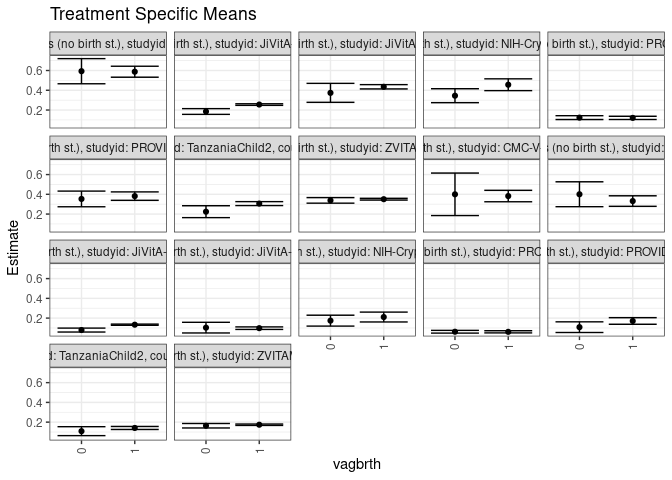

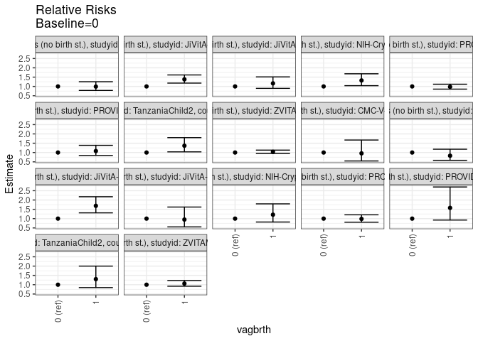

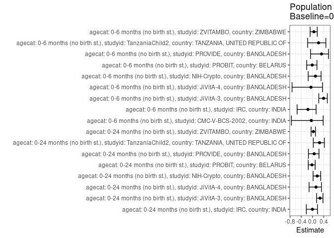

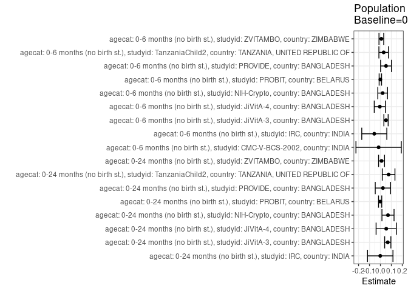

## Results Table

### Parameter: TSM

| agecat | studyid | country | intervention_level | baseline_level | estimate | ci_lower | ci_upper |
| --- | --- | --- | --- | --- | --- | --- | --- |
| 0-24 months (no birth st.) | IRC | INDIA | 0 | NA | 0.5932665 | 0.4660336 | 0.7204994 |
| 0-24 months (no birth st.) | IRC | INDIA | 1 | NA | 0.5879360 | 0.5323029 | 0.6435691 |
| 0-24 months (no birth st.) | JiVitA-3 | BANGLADESH | 0 | NA | 0.1850365 | 0.1560661 | 0.2140069 |
| 0-24 months (no birth st.) | JiVitA-3 | BANGLADESH | 1 | NA | 0.2554923 | 0.2475697 | 0.2634148 |
| 0-24 months (no birth st.) | JiVitA-4 | BANGLADESH | 0 | NA | 0.3737912 | 0.2778040 | 0.4697784 |
| 0-24 months (no birth st.) | JiVitA-4 | BANGLADESH | 1 | NA | 0.4352899 | 0.4136477 | 0.4569320 |
| 0-24 months (no birth st.) | NIH-Crypto | BANGLADESH | 0 | NA | 0.3450720 | 0.2744577 | 0.4156863 |
| 0-24 months (no birth st.) | NIH-Crypto | BANGLADESH | 1 | NA | 0.4561901 | 0.3965399 | 0.5158404 |
| 0-24 months (no birth st.) | PROBIT | BELARUS | 0 | NA | 0.1230237 | 0.1037281 | 0.1423193 |
| 0-24 months (no birth st.) | PROBIT | BELARUS | 1 | NA | 0.1204024 | 0.1041301 | 0.1366748 |
| 0-24 months (no birth st.) | PROVIDE | BANGLADESH | 0 | NA | 0.3531963 | 0.2736826 | 0.4327100 |
| 0-24 months (no birth st.) | PROVIDE | BANGLADESH | 1 | NA | 0.3816697 | 0.3390958 | 0.4242436 |
| 0-24 months (no birth st.) | TanzaniaChild2 | TANZANIA, UNITED REPUBLIC OF | 0 | NA | 0.2241186 | 0.1638879 | 0.2843494 |
| 0-24 months (no birth st.) | TanzaniaChild2 | TANZANIA, UNITED REPUBLIC OF | 1 | NA | 0.3059611 | 0.2858569 | 0.3260653 |
| 0-24 months (no birth st.) | ZVITAMBO | ZIMBABWE | 0 | NA | 0.3383778 | 0.3101301 | 0.3666255 |
| 0-24 months (no birth st.) | ZVITAMBO | ZIMBABWE | 1 | NA | 0.3505236 | 0.3417938 | 0.3592534 |
| 0-6 months (no birth st.) | CMC-V-BCS-2002 | INDIA | 0 | NA | 0.4000000 | 0.1849281 | 0.6150719 |
| 0-6 months (no birth st.) | CMC-V-BCS-2002 | INDIA | 1 | NA | 0.3823529 | 0.3245019 | 0.4402040 |
| 0-6 months (no birth st.) | IRC | INDIA | 0 | NA | 0.4005655 | 0.2745013 | 0.5266297 |
| 0-6 months (no birth st.) | IRC | INDIA | 1 | NA | 0.3316507 | 0.2783452 | 0.3849563 |
| 0-6 months (no birth st.) | JiVitA-3 | BANGLADESH | 0 | NA | 0.0789227 | 0.0590306 | 0.0988149 |
| 0-6 months (no birth st.) | JiVitA-3 | BANGLADESH | 1 | NA | 0.1332067 | 0.1274222 | 0.1389913 |
| 0-6 months (no birth st.) | JiVitA-4 | BANGLADESH | 0 | NA | 0.1033359 | 0.0493175 | 0.1573544 |
| 0-6 months (no birth st.) | JiVitA-4 | BANGLADESH | 1 | NA | 0.0981088 | 0.0851910 | 0.1110267 |
| 0-6 months (no birth st.) | NIH-Crypto | BANGLADESH | 0 | NA | 0.1740787 | 0.1187831 | 0.2293743 |
| 0-6 months (no birth st.) | NIH-Crypto | BANGLADESH | 1 | NA | 0.2107101 | 0.1608735 | 0.2605467 |
| 0-6 months (no birth st.) | PROBIT | BELARUS | 0 | NA | 0.0620345 | 0.0480671 | 0.0760018 |
| 0-6 months (no birth st.) | PROBIT | BELARUS | 1 | NA | 0.0610786 | 0.0499409 | 0.0722163 |
| 0-6 months (no birth st.) | PROVIDE | BANGLADESH | 0 | NA | 0.1083225 | 0.0542115 | 0.1624336 |
| 0-6 months (no birth st.) | PROVIDE | BANGLADESH | 1 | NA | 0.1709360 | 0.1375484 | 0.2043236 |
| 0-6 months (no birth st.) | TanzaniaChild2 | TANZANIA, UNITED REPUBLIC OF | 0 | NA | 0.1085063 | 0.0631892 | 0.1538235 |
| 0-6 months (no birth st.) | TanzaniaChild2 | TANZANIA, UNITED REPUBLIC OF | 1 | NA | 0.1410923 | 0.1259082 | 0.1562764 |
| 0-6 months (no birth st.) | ZVITAMBO | ZIMBABWE | 0 | NA | 0.1636314 | 0.1410114 | 0.1862513 |
| 0-6 months (no birth st.) | ZVITAMBO | ZIMBABWE | 1 | NA | 0.1738384 | 0.1668932 | 0.1807835 |

### Parameter: E(Y)

| agecat | studyid | country | intervention_level | baseline_level | estimate | ci_lower | ci_upper |
| --- | --- | --- | --- | --- | --- | --- | --- |
| 0-24 months (no birth st.) | IRC | INDIA | NA | NA | 0.5916667 | 0.5408218 | 0.6425115 |
| 0-24 months (no birth st.) | JiVitA-3 | BANGLADESH | NA | NA | 0.2522552 | 0.2445070 | 0.2600034 |
| 0-24 months (no birth st.) | JiVitA-4 | BANGLADESH | NA | NA | 0.4270574 | 0.4065290 | 0.4475857 |
| 0-24 months (no birth st.) | NIH-Crypto | BANGLADESH | NA | NA | 0.4143519 | 0.3678455 | 0.4608582 |
| 0-24 months (no birth st.) | PROBIT | BELARUS | NA | NA | 0.1205488 | 0.1047261 | 0.1363714 |
| 0-24 months (no birth st.) | PROVIDE | BANGLADESH | NA | NA | 0.3759874 | 0.3382238 | 0.4137509 |
| 0-24 months (no birth st.) | TanzaniaChild2 | TANZANIA, UNITED REPUBLIC OF | NA | NA | 0.2990485 | 0.2799429 | 0.3181541 |
| 0-24 months (no birth st.) | ZVITAMBO | ZIMBABWE | NA | NA | 0.3487442 | 0.3403900 | 0.3570984 |
| 0-6 months (no birth st.) | CMC-V-BCS-2002 | INDIA | NA | NA | 0.3835616 | 0.3276935 | 0.4394298 |
| 0-6 months (no birth st.) | IRC | INDIA | NA | NA | 0.3444444 | 0.2952897 | 0.3935992 |
| 0-6 months (no birth st.) | JiVitA-3 | BANGLADESH | NA | NA | 0.1301138 | 0.1245115 | 0.1357160 |
| 0-6 months (no birth st.) | JiVitA-4 | BANGLADESH | NA | NA | 0.0978125 | 0.0850264 | 0.1105986 |
| 0-6 months (no birth st.) | NIH-Crypto | BANGLADESH | NA | NA | 0.1944444 | 0.1570803 | 0.2318086 |
| 0-6 months (no birth st.) | PROBIT | BELARUS | NA | NA | 0.0614448 | 0.0507274 | 0.0721623 |
| 0-6 months (no birth st.) | PROVIDE | BANGLADESH | NA | NA | 0.1595577 | 0.1310079 | 0.1881074 |
| 0-6 months (no birth st.) | TanzaniaChild2 | TANZANIA, UNITED REPUBLIC OF | NA | NA | 0.1381966 | 0.1237955 | 0.1525978 |
| 0-6 months (no birth st.) | ZVITAMBO | ZIMBABWE | NA | NA | 0.1721902 | 0.1655693 | 0.1788111 |

### Parameter: RR

| agecat | studyid | country | intervention_level | baseline_level | estimate | ci_lower | ci_upper |
| --- | --- | --- | --- | --- | --- | --- | --- |
| 0-24 months (no birth st.) | IRC | INDIA | 0 | 0 | 1.0000000 | 1.0000000 | 1.000000 |
| 0-24 months (no birth st.) | IRC | INDIA | 1 | 0 | 0.9910149 | 0.7841886 | 1.252391 |
| 0-24 months (no birth st.) | JiVitA-3 | BANGLADESH | 0 | 0 | 1.0000000 | 1.0000000 | 1.000000 |
| 0-24 months (no birth st.) | JiVitA-3 | BANGLADESH | 1 | 0 | 1.3807669 | 1.1786833 | 1.617498 |
| 0-24 months (no birth st.) | JiVitA-4 | BANGLADESH | 0 | 0 | 1.0000000 | 1.0000000 | 1.000000 |
| 0-24 months (no birth st.) | JiVitA-4 | BANGLADESH | 1 | 0 | 1.1645267 | 0.8962567 | 1.513096 |
| 0-24 months (no birth st.) | NIH-Crypto | BANGLADESH | 0 | 0 | 1.0000000 | 1.0000000 | 1.000000 |
| 0-24 months (no birth st.) | NIH-Crypto | BANGLADESH | 1 | 0 | 1.3220144 | 1.0407747 | 1.679251 |
| 0-24 months (no birth st.) | PROBIT | BELARUS | 0 | 0 | 1.0000000 | 1.0000000 | 1.000000 |
| 0-24 months (no birth st.) | PROBIT | BELARUS | 1 | 0 | 0.9786929 | 0.8559841 | 1.118993 |
| 0-24 months (no birth st.) | PROVIDE | BANGLADESH | 0 | 0 | 1.0000000 | 1.0000000 | 1.000000 |
| 0-24 months (no birth st.) | PROVIDE | BANGLADESH | 1 | 0 | 1.0806163 | 0.8422891 | 1.386379 |
| 0-24 months (no birth st.) | TanzaniaChild2 | TANZANIA, UNITED REPUBLIC OF | 0 | 0 | 1.0000000 | 1.0000000 | 1.000000 |
| 0-24 months (no birth st.) | TanzaniaChild2 | TANZANIA, UNITED REPUBLIC OF | 1 | 0 | 1.3651748 | 1.0358799 | 1.799149 |
| 0-24 months (no birth st.) | ZVITAMBO | ZIMBABWE | 0 | 0 | 1.0000000 | 1.0000000 | 1.000000 |
| 0-24 months (no birth st.) | ZVITAMBO | ZIMBABWE | 1 | 0 | 1.0358943 | 0.9499173 | 1.129653 |
| 0-6 months (no birth st.) | CMC-V-BCS-2002 | INDIA | 0 | 0 | 1.0000000 | 1.0000000 | 1.000000 |
| 0-6 months (no birth st.) | CMC-V-BCS-2002 | INDIA | 1 | 0 | 0.9558824 | 0.5467942 | 1.671033 |
| 0-6 months (no birth st.) | IRC | INDIA | 0 | 0 | 1.0000000 | 1.0000000 | 1.000000 |
| 0-6 months (no birth st.) | IRC | INDIA | 1 | 0 | 0.8279563 | 0.5814883 | 1.178892 |
| 0-6 months (no birth st.) | JiVitA-3 | BANGLADESH | 0 | 0 | 1.0000000 | 1.0000000 | 1.000000 |
| 0-6 months (no birth st.) | JiVitA-3 | BANGLADESH | 1 | 0 | 1.6878123 | 1.3095602 | 2.175318 |
| 0-6 months (no birth st.) | JiVitA-4 | BANGLADESH | 0 | 0 | 1.0000000 | 1.0000000 | 1.000000 |
| 0-6 months (no birth st.) | JiVitA-4 | BANGLADESH | 1 | 0 | 0.9494164 | 0.5555368 | 1.622560 |
| 0-6 months (no birth st.) | NIH-Crypto | BANGLADESH | 0 | 0 | 1.0000000 | 1.0000000 | 1.000000 |
| 0-6 months (no birth st.) | NIH-Crypto | BANGLADESH | 1 | 0 | 1.2104303 | 0.8168836 | 1.793574 |
| 0-6 months (no birth st.) | PROBIT | BELARUS | 0 | 0 | 1.0000000 | 1.0000000 | 1.000000 |
| 0-6 months (no birth st.) | PROBIT | BELARUS | 1 | 0 | 0.9845920 | 0.8045404 | 1.204938 |
| 0-6 months (no birth st.) | PROVIDE | BANGLADESH | 0 | 0 | 1.0000000 | 1.0000000 | 1.000000 |
| 0-6 months (no birth st.) | PROVIDE | BANGLADESH | 1 | 0 | 1.5780282 | 0.9223913 | 2.699693 |
| 0-6 months (no birth st.) | TanzaniaChild2 | TANZANIA, UNITED REPUBLIC OF | 0 | 0 | 1.0000000 | 1.0000000 | 1.000000 |
| 0-6 months (no birth st.) | TanzaniaChild2 | TANZANIA, UNITED REPUBLIC OF | 1 | 0 | 1.3003144 | 0.8453748 | 2.000080 |
| 0-6 months (no birth st.) | ZVITAMBO | ZIMBABWE | 0 | 0 | 1.0000000 | 1.0000000 | 1.000000 |
| 0-6 months (no birth st.) | ZVITAMBO | ZIMBABWE | 1 | 0 | 1.0623782 | 0.9203979 | 1.226260 |

### Parameter: PAR

| agecat | studyid | country | intervention_level | baseline_level | estimate | ci_lower | ci_upper |
| --- | --- | --- | --- | --- | --- | --- | --- |
| 0-24 months (no birth st.) | IRC | INDIA | 0 | NA | -0.0015998 | -0.1179342 | 0.1147345 |
| 0-24 months (no birth st.) | JiVitA-3 | BANGLADESH | 0 | NA | 0.0672187 | 0.0386647 | 0.0957727 |
| 0-24 months (no birth st.) | JiVitA-4 | BANGLADESH | 0 | NA | 0.0532661 | -0.0395886 | 0.1461209 |
| 0-24 months (no birth st.) | NIH-Crypto | BANGLADESH | 0 | NA | 0.0692799 | 0.0139542 | 0.1246055 |
| 0-24 months (no birth st.) | PROBIT | BELARUS | 0 | NA | -0.0024749 | -0.0171573 | 0.0122075 |
| 0-24 months (no birth st.) | PROVIDE | BANGLADESH | 0 | NA | 0.0227911 | -0.0474264 | 0.0930086 |
| 0-24 months (no birth st.) | TanzaniaChild2 | TANZANIA, UNITED REPUBLIC OF | 0 | NA | 0.0749298 | 0.0169281 | 0.1329315 |
| 0-24 months (no birth st.) | ZVITAMBO | ZIMBABWE | 0 | NA | 0.0103664 | -0.0166337 | 0.0373665 |
| 0-6 months (no birth st.) | CMC-V-BCS-2002 | INDIA | 0 | NA | -0.0164384 | -0.2239010 | 0.1910243 |
| 0-6 months (no birth st.) | IRC | INDIA | 0 | NA | -0.0561211 | -0.1707381 | 0.0584960 |
| 0-6 months (no birth st.) | JiVitA-3 | BANGLADESH | 0 | NA | 0.0511910 | 0.0316022 | 0.0707798 |
| 0-6 months (no birth st.) | JiVitA-4 | BANGLADESH | 0 | NA | -0.0055234 | -0.0564524 | 0.0454056 |
| 0-6 months (no birth st.) | NIH-Crypto | BANGLADESH | 0 | NA | 0.0203658 | -0.0239156 | 0.0646472 |
| 0-6 months (no birth st.) | PROBIT | BELARUS | 0 | NA | -0.0005896 | -0.0117213 | 0.0105421 |
| 0-6 months (no birth st.) | PROVIDE | BANGLADESH | 0 | NA | 0.0512351 | 0.0016902 | 0.1007800 |
| 0-6 months (no birth st.) | TanzaniaChild2 | TANZANIA, UNITED REPUBLIC OF | 0 | NA | 0.0296903 | -0.0139205 | 0.0733012 |
| 0-6 months (no birth st.) | ZVITAMBO | ZIMBABWE | 0 | NA | 0.0085588 | -0.0131233 | 0.0302410 |

### Parameter: PAF

| agecat | studyid | country | intervention_level | baseline_level | estimate | ci_lower | ci_upper |
| --- | --- | --- | --- | --- | --- | --- | --- |
| 0-24 months (no birth st.) | IRC | INDIA | 0 | NA | -0.0027039 | -0.2199261 | 0.1758393 |
| 0-24 months (no birth st.) | JiVitA-3 | BANGLADESH | 0 | NA | 0.2664710 | 0.1445091 | 0.3710456 |
| 0-24 months (no birth st.) | JiVitA-4 | BANGLADESH | 0 | NA | 0.1247283 | -0.1225382 | 0.3175283 |
| 0-24 months (no birth st.) | NIH-Crypto | BANGLADESH | 0 | NA | 0.1672005 | 0.0218464 | 0.2909550 |
| 0-24 months (no birth st.) | PROBIT | BELARUS | 0 | NA | -0.0205305 | -0.1505367 | 0.0947854 |
| 0-24 months (no birth st.) | PROVIDE | BANGLADESH | 0 | NA | 0.0606166 | -0.1460695 | 0.2300282 |
| 0-24 months (no birth st.) | TanzaniaChild2 | TANZANIA, UNITED REPUBLIC OF | 0 | NA | 0.2505608 | 0.0292900 | 0.4213935 |
| 0-24 months (no birth st.) | ZVITAMBO | ZIMBABWE | 0 | NA | 0.0297250 | -0.0508707 | 0.1041394 |
| 0-6 months (no birth st.) | CMC-V-BCS-2002 | INDIA | 0 | NA | -0.0428571 | -0.7517776 | 0.3791729 |
| 0-6 months (no birth st.) | IRC | INDIA | 0 | NA | -0.1629321 | -0.5483342 | 0.1265380 |
| 0-6 months (no birth st.) | JiVitA-3 | BANGLADESH | 0 | NA | 0.3934330 | 0.2232508 | 0.5263290 |
| 0-6 months (no birth st.) | JiVitA-4 | BANGLADESH | 0 | NA | -0.0564695 | -0.7280058 | 0.3540949 |
| 0-6 months (no birth st.) | NIH-Crypto | BANGLADESH | 0 | NA | 0.1047382 | -0.1533773 | 0.3050898 |
| 0-6 months (no birth st.) | PROBIT | BELARUS | 0 | NA | -0.0095958 | -0.2084099 | 0.1565083 |
| 0-6 months (no birth st.) | PROVIDE | BANGLADESH | 0 | NA | 0.3211072 | -0.0700333 | 0.5692700 |
| 0-6 months (no birth st.) | TanzaniaChild2 | TANZANIA, UNITED REPUBLIC OF | 0 | NA | 0.2148413 | -0.1732747 | 0.4745695 |
| 0-6 months (no birth st.) | ZVITAMBO | ZIMBABWE | 0 | NA | 0.0497058 | -0.0849368 | 0.1676390 |